# Ultimatum Game (Proposer)

Author

Liam Doyle

## Description

This document is a summary of the analyses performed for the fifth meta-analytic model conducted in Study 1 of my dissertation. This model examined the relationship between psychopathy and exploitative behavior in the Ultimatum Game as the Proposer.

This model utilized a multi-level or hierarchical approach in order to deal with the issue of nested effect sizes (i.e., some studies contributing more than one effect size to the analysis).

## Loading Packages

All relevant packages loaded below.

```r
library(tidyverse)
library(meta)
library(metafor)
library(devtools)
library(esc)
library(effectsize)
library(psych)
library(dmetar)
library(readxl)
```

## Loading Data

Loading the excel spreadsheet with all study information.

```r
UG_Proposer <- read_excel("UG_Proposer.xlsx")
```

## Recoding Variables as Factors

Recoding relevant variables (i.e., moderators in the analysis) as factors.

```r
UG_Proposer$Sample_Source <- factor(UG_Proposer$Sample_Source,
                                  levels = c(0, 1, 2, 3),
                                  labels = c("Community", "Student", "Inmate", "Mixed"))

UG_Proposer$Publication_Status <- factor(UG_Proposer$Publication_Status,
                                       levels = c(0, 1),
                                       labels = c("Unpublished", "Published"))

UG_Proposer$Measure_coded <- factor(UG_Proposer$Measure_coded,
                                       levels = c(0, 1, 2, 3, 4, 5, 6),
                                       labels = c("SRP", "PCL", "PPI",
                                                  "LSRP", "TriPM", "SD3",
                                                  "DD"))

UG_Proposer$Iterated <- factor(UG_Proposer$Iterated,
                                       levels = c(0, 1),
                                       labels = c("One-shot", "Iterated"))

UG_Proposer$Perceived_Opponent <- factor(UG_Proposer$Perceived_Opponent,
                                 levels = c(0, 1),
                                 labels = c("No", "Yes"))

UG_Proposer$Social_role <- factor(UG_Proposer$Social_role,
                                       levels = c(0, 1),
                                       labels = c("Close member", "Distant member"))

UG_Proposer$Incentives <- factor(UG_Proposer$Incentives,
                               levels = c(0, 1, 2),
                               labels = c("Not incentivized", "Participation incentivized",
                                          "Performance incentivized"))

UG_Proposer$Experimental_Manipulation <- factor(UG_Proposer$Experimental_Manipulation,
                                                levels = c(0, 1),
                                                labels = c("No Manipulation",
                                                           "Manipulation"))
```

## Computing Additional Variables

Performing mathematical computations to compute relevant variables such as Fisher’s *z*, as well as it’s standard error and variance.

```r
UG_Proposer <- UG_Proposer %>%
  mutate(z_psyc_coop = 0.5 * log((1 + Psych_Coop)/(1 - Psych_Coop)))

UG_Proposer <- UG_Proposer %>%
  mutate(z_se_psyc_coop = 1/(sqrt(n_effect - 3)))

UG_Proposer <- UG_Proposer %>%
  mutate(var_z_psyc_coop = (z_se_psyc_coop^2))
```

## Multi-Level Random-Effects Model of Psychopathy on Cooperation in the Ultimatum Game (Proposer)

As noted in the heading and the project description, this model utilizes a multi-level or hierarchical approach to modelling the relationship between psychopathy and cooperation in the Ultimatum Game as the Proposer. This is due to the fact that several of the studies included in the meta-analysis contributed more than one effect size to the analysis (e.g., a study using more than one measure of psychopathy). The contemporary recommendation for addressing this issue is to use a multi-level approach to cluster these data points - rather than simply aggregating them and ignoring potential differences between the effects.

In addition, I have made the decision to use a random-effects model for the meta-analyses in this dissertation. The fixed-effects model makes untenable assumptions about the sources of variance in the effect sizes (i.e., assuming that all effect sizes are from a homogenous population, and the only source of variance in effect sizes is from sampling error). The assumptions of a fixed-effects model also stand in contradiction to the intended moderator analyses which make up a substantial portion of our later analyses.

### Creation of the Model

```r
full.model <- rma.mv(yi = z_psyc_coop,
                     V = var_z_psyc_coop,
                     slab = Study,
                     data = UG_Proposer,
                     random = ~ 1 | Study/Effect_size_ID,
                     test = "t",
                     method = "REML")

summary(full.model)
```

```
Multivariate Meta-Analysis Model (k = 11; method: REML)

  logLik  Deviance       AIC       BIC      AICc
  8.9598  -17.9197  -11.9197  -11.0119   -7.9197

Variance Components:

            estim    sqrt  nlvls  fixed                factor
sigma^2.1  0.0000  0.0000     10     no                 Study
sigma^2.2  0.0000  0.0000     11     no  Study/Effect_size_ID

Test for Heterogeneity:
Q(df = 10) = 9.4946, p-val = 0.4859

Model Results:

estimate      se     tval  df    pval    ci.lb    ci.ub
 -0.0564  0.0238  -2.3710  10  0.0392  -0.1093  -0.0034  *

---
Signif. codes:  0 '***' 0.001 '**' 0.01 '*' 0.05 '.' 0.1 ' ' 1
```

```r
convert_z2r(-.0564)
```

```
[1] -0.05634027
```

As we can see, the model estimates that the meta-analytic effect size is *r* = -.056, 95% CI [-.109, -.003]. Cochran’s *Q* statistic was not significant, indicating little to no between-study heterogeneity.

### Distribution of Variance Across Levels

This function, provided by the package *dmetar*, calculates a multilevel version of *I*<sup>2</sup>. Level 1 variance corresponds to sampling error variance. Level 2 variance corresponds to within-study (or cluster) variance. Level 3 variance corresponds to between-study variance.

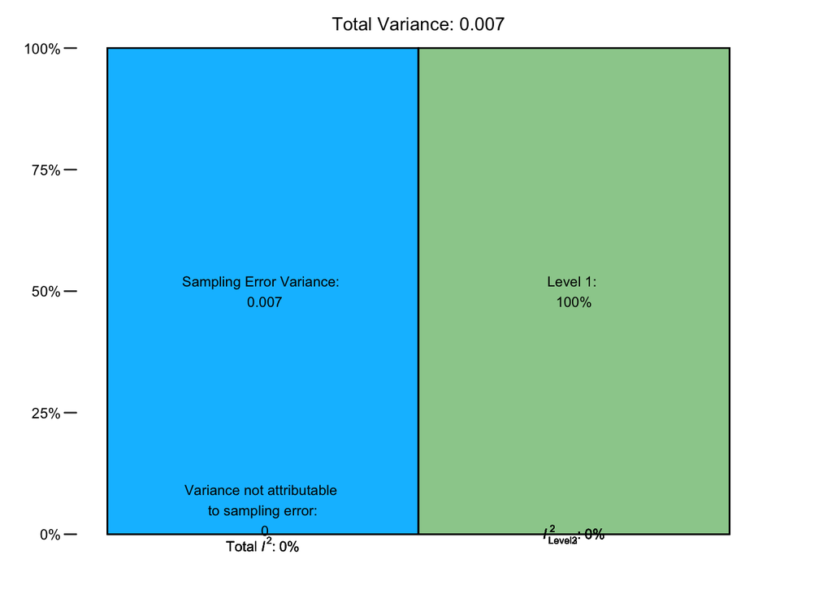

```r
i2 <- var.comp(full.model)

plot(i2)
```

In our case, all of the variation between effect sizes has been attributed to sampling error. The *I*<sup>2</sup> value for Levels 2 and 3 suggest that there is no heterogeneity between- or within-studies (i.e., effect sizes differ only due to sampling error).

### Comparing Models

```r
l3.removed <- rma.mv(yi = z_psyc_coop,
                     V = var_z_psyc_coop,
                     slab = Study,
                     data = UG_Proposer,
                     random = ~ 1 | Study/Effect_size_ID,
                     test = "t",
                     method = "REML",
                     sigma2 = c(0, NA))

anova(full.model, l3.removed)
```

```
        df      AIC      BIC     AICc logLik    LRT   pval     QE
Full     3 -11.9197 -11.0119  -7.9197 8.9598               9.4946
Reduced  2 -13.9197 -13.3145 -12.2054 8.9598 0.0000 1.0000 9.4946
```

### Forest Plot of the Model

Note: This plot had to be generated using a simple random-effects meta-analytic model, as there is not a package available in *R* to accommodate the creation of forest plots for multi-level meta-analytic models.

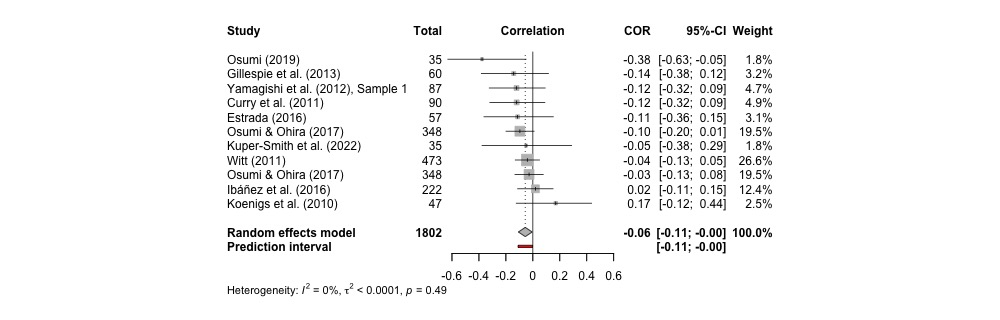

## Tests of Publication Bias

In this section, I examined the possibility of publication bias via the visual examination of funnel plots, Egger’s regression test, a simple meta-regression which regressed publication status (as a binary factor) on effect size, and PET-PEESE methods.

### Funnel Plot

This funnel plot does possess some asymmetry (i.e., the pocket of missing studies to the right of the effect size estimate at an *SE* of ~.10). Asymmetry in a funnel plot has several possible sources (Page et al., 2020):

- Publication bias and other reporting biases;
- Variability in methodological quality;
- Between-study heterogeneity;
- Artefactual variance (i.e., via the correlation between effect sizes and their standard error)
- Chance

While it is certainly possible that the asymmetry is attributable to publication bias, there are also potential explanations for the phenomenon.

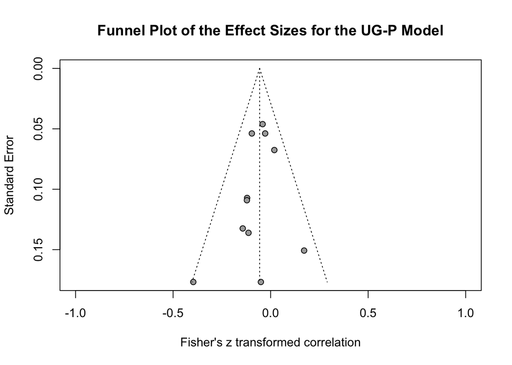

```r
meta::funnel(m.cor,
             xlim = c(-1, 1),
             studlab = FALSE)

title("Funnel Plot of the Effect Sizes for the UG-P Model")
```

### Egger’s Regression Test

Egger’s regression test (Egger et al., 1997) is a method that provides a statistical test of asymmetry in a funnel plot. It involves the prediction of standardized effect sizes on their precision.

The intercept (i.e., $\beta_0$) is of primary interest, representing the asymmetry of the plot. NHST can be used to test the null hypothesis that the intercept is equal to zero, indicating symmetry in the funnel plot. Conversely, a rejected null hypothesis for the intercept indicates asymmetry in the funnel plot - potentially due to publication bias.

The slope (i.e., $\beta_1$) represents the effect size adjusted for precision. It is expected to be consistent with the overall meta-analytic effect.

Reported below is the significance test and parameter estimate for the intercept.

```r
metabias(m.cor,
         method.bias = "linreg")
```

```
Review:     Psychopathy and Cooperation as the Proposer in the UG

Linear regression test of funnel plot asymmetry

Test result: t = -0.98, df = 9, p-value = 0.3519
Bias estimate: -0.6502 (SE = 0.6623)

Details:
- multiplicative residual heterogeneity variance (tau^2 = 0.9529)
- predictor: standard error
- weight:    inverse variance
- reference: Egger et al. (1997), BMJ
```

The intercept was not significant, indicating that there is not a substantial amount of asymmetry in the funnel plot.

### Publication Status as a Moderator of Effect Size

Simple meta-regression was used to predict effect sizes from publication status as a factor (i.e., 0 = unpublished, 1 = published).

```r
mod.model.pub <- rma.mv(yi = z_psyc_coop,
                        V = var_z_psyc_coop,
                        slab = Study,
                        data = UG_Proposer,
                        random = ~ 1 | Study/Effect_size_ID,
                        test = "t",
                        method = "REML",
                        mods = ~ Publication_Status)


summary(mod.model.pub)
```

```
Multivariate Meta-Analysis Model (k = 11; method: REML)

  logLik  Deviance       AIC       BIC      AICc
  7.3217  -14.6435   -6.6435   -5.8546    3.3565

Variance Components:

            estim    sqrt  nlvls  fixed                factor
sigma^2.1  0.0000  0.0000     10     no                 Study
sigma^2.2  0.0000  0.0000     11     no  Study/Effect_size_ID

Test for Residual Heterogeneity:
QE(df = 9) = 9.4454, p-val = 0.3972

Test of Moderators (coefficient 2):
F(df1 = 1, df2 = 9) = 0.0492, p-val = 0.8293

Model Results:

                             estimate      se     tval  df    pval    ci.lb
intrcpt                       -0.0486  0.0424  -1.1455   9  0.2816  -0.1445
Publication_StatusPublished   -0.0114  0.0512  -0.2219   9  0.8293  -0.1272
                              ci.ub
intrcpt                      0.0474
Publication_StatusPublished  0.1045

---
Signif. codes:  0 '***' 0.001 '**' 0.01 '*' 0.05 '.' 0.1 ' ' 1
```

The omnibus test indicates that there is no significant difference between published and unpublished studies, *F*(1, 9) = 0.05, *p* = .829.

### PET & PEESE Analyses

The PET (Precision-Effect Test) and PEESE (Precision-Effect Estimate with Standard Error) are two analytical methods designed to address publication bias in meta-analyses.

The former, PET analysis, is designed to determine the degree to which small-study effects and publication bias impact a meta-analysis. To do so, effect sizes are predicted from their standard errors. This analysis is used to provide evidence that a genuine effect exists beyond the effect of small-study effects/publication bias.

#### PET Analysis

The key element of the PET analysis is the estimate for $\beta_0$ or the intercept of the regression. According to the logic for PET analysis, a non-significant intercept indicates that no genuine effect occurs beyond small-study effects/publication bias. In contrast, a significant intercept provides evidence for a true effect.

That being said, one potential issue with both PET and PEESE analysis is the assumption that there is a homogenous distribution underlying effect sizes. Conceptually, this is similar to the assumption underlying fixed-effects meta-analyses (https://willgervais.com/blog/2015/6/25/putting-pet-peese-to-the-test-1). While this is problematic in and of itself, we will proceed using the PET-PEESE method.

```r
pet_model <- rma.mv(yi = z_psyc_coop,
                    V = var_z_psyc_coop,
                    mods = ~ z_se_psyc_coop,
                    slab = Study,
                    data = UG_Proposer,
                    random = ~ 1 | Study/Effect_size_ID,
                    test = "t",
                    method = "REML")

summary(pet_model)
```

```
Multivariate Meta-Analysis Model (k = 11; method: REML)

  logLik  Deviance       AIC       BIC      AICc
  8.0844  -16.1688   -8.1688   -7.3799    1.8312

Variance Components:

            estim    sqrt  nlvls  fixed                factor
sigma^2.1  0.0000  0.0000     10     no                 Study
sigma^2.2  0.0000  0.0000     11     no  Study/Effect_size_ID

Test for Residual Heterogeneity:
QE(df = 9) = 8.5762, p-val = 0.4773

Test of Moderators (coefficient 2):
F(df1 = 1, df2 = 9) = 0.9184, p-val = 0.3629

Model Results:

                estimate      se     tval  df    pval    ci.lb   ci.ub
intrcpt          -0.0104  0.0535  -0.1952   9  0.8496  -0.1315  0.1106
z_se_psyc_coop   -0.6502  0.6785  -0.9583   9  0.3629  -2.1850  0.8846

---
Signif. codes:  0 '***' 0.001 '**' 0.01 '*' 0.05 '.' 0.1 ' ' 1
```

As seen in the output, the intercept in the model is not significant (*p* = .850). On the basis of the test, this indicates that no true effect exists beyond publication bias. According to the PET-PEESE method, we should not proceed to the PEESE step of modelling. However, the PET-PEESE method has been acknowledged by its creator (Stanley, 2017) to (a) perform poorly under conditions of small sample size (i.e., k < 20) and high between-study heterogeneity (i.e., *I*<sup>2</sup> > 80) and (b) heavily over-corrects for bias in the data (Carter et al., 2019). While we have no between-/within-study heterogeneity indicated by our *I*<sup>2</sup> value, we do have significantly fewer studies than we should (i.e., *k* = 11) for this analysis.

#### PEESE Analysis

PEESE analysis aims to produce a precise estimate of the true effect size after accounting for sampling error, small-study effects, and publication bias. It does so by creating a regression where effect sizes are predicted by the squared standard errors of studies.

Again, the primary parameter estimate of interest is $\beta_0$, which indicates the estimate of the true effect size (after adjusting for sampling error, small-study effects, and publication bias). Significance tests are interpreted such that a significant intercept indicates a significant meta-analytic effect size.

A secondary parameter estimate of interest is $\beta_1$, which indicates the relationship between effect sizes and their variances. When this is significant, there is evidence that effect sizes are systematically related to the estimate of their precision (i.e., their variance), which may suggest the presence of small-study effects or publication bias.

More particularly, a positive slope indicates that larger variances (with larger standard errors, and, oftentimes, smaller sample sizes) report larger effect sizes. This is representative of the typical “small-study effect” and indicates potential publication bias.

In contrast, a negative slope suggests that smaller studies report smaller effect sizes and larger studies report larger effect sizes. This may indicate other sources of bias or sources of heterogeneity impacting the results.

```r
peese_model <- rma.mv(yi = z_psyc_coop,
                      V = var_z_psyc_coop,
                      mods = ~ var_z_psyc_coop,
                      slab = Study,
                      data = UG_Proposer,
                      random = ~ 1 | Study/Effect_size_ID,
                      test = "t",
                      method = "REML")

summary(peese_model)
```

```
Multivariate Meta-Analysis Model (k = 11; method: REML)

  logLik  Deviance       AIC       BIC      AICc
  8.2290  -16.4580   -8.4580   -7.6691    1.5420

Variance Components:

            estim    sqrt  nlvls  fixed                factor
sigma^2.1  0.0000  0.0000     10     no                 Study
sigma^2.2  0.0000  0.0000     11     no  Study/Effect_size_ID

Test for Residual Heterogeneity:
QE(df = 9) = 8.4823, p-val = 0.4864

Test of Moderators (coefficient 2):
F(df1 = 1, df2 = 9) = 1.0123, p-val = 0.3406

Model Results:

                 estimate      se     tval  df    pval     ci.lb   ci.ub
intrcpt           -0.0354  0.0316  -1.1182   9  0.2924   -0.1069  0.0362
var_z_psyc_coop   -3.3767  3.3562  -1.0061   9  0.3406  -10.9689  4.2155

---
Signif. codes:  0 '***' 0.001 '**' 0.01 '*' 0.05 '.' 0.1 ' ' 1
```

```r
convert_z2r(-.0354)
```

```
[1] -0.03538522
```

As seen in the model output, the PEESE method indicates that the true effect size is *r* = -.035 and non-significant at *p* = .292. This differs slightly from our original estimate of the effect at *r* = -.056.

The slope coefficient indicates a non-significant, negative relationship between effect sizes and their variances (see above). The fact that this relationship is not significant (and negative) indicates that publication bias does not have a substantial impact on the effect sizes.

To illustrate the slope estimated by the model visually, we will plot the regression.

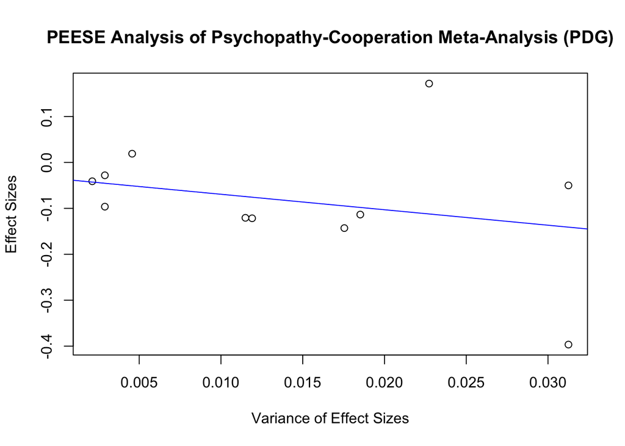

```r
plot(
  UG_Proposer$var_z_psyc_coop, UG_Proposer$z_psyc_coop,
  xlab = "Variance of Effect Sizes",
  ylab = "Effect Sizes",
  main = "PEESE Analysis of Psychopathy-Cooperation Meta-Analysis (PDG)"
)
abline(a = coef(peese_model)[1], b = coef(peese_model)[2], col = "blue")
```

### Fail-Safe *N*

A variation of Orwin’s (1983) fail-safe N test was used to indicate the number of studies with null effects needed to reduce the effect size to a practically irrelevant size (Viechtbauer, 2010). Practical insignificance was demarked by an effect size of r = |.05|, depending on the direction of the summary effect.

```r
fail.safe <- rma(yi = z_psyc_coop,
                 vi = var_z_psyc_coop,
                 slab = Study,
                 data = UG_Proposer,
                 method = "REML")

fsn(fail.safe, type = "General", target = 0.05)
```

```
Fail-safe N Calculation Using the General Approach

Average Effect Size:         -0.0564 (with file drawer: -0.0482)
Amount of Heterogeneity:      0.0000 (with file drawer:  0.0004)
Observed Significance Level:  0.0177 (with file drawer:  0.0375)
Target Effect Size:          -0.0500

Fail-safe N: 3
```

## Moderator Analysis

Afterwards, a series of moderators were tested. The list of moderators was generated *a priori* using the Affordance-Based Framework of Prosocial Behavior, original ideas, and ideas from previous meta-analyses on psychopathy and cooperation (e.g., Thielmann et al., 2020). In-depth reasoning for the selection of moderators is provided in the dissertation package.

Multiple meta-regression was not used in our study due to constraints arising from (a) a smaller numbers of studies being used (b) the large number of moderators being considered (Higgins & Thompson, 2004). As such, our study explored individual moderators with simple meta-regression analysis. For each model where there were over 10 studies (Deeks et al., 2023), moderators of interest were examined individually using simple meta-regression.

### *N* as a Moderator of Effect Size

```r
mod.model.n <- rma.mv(yi = z_psyc_coop,
                      V = var_z_psyc_coop,
                      slab = Study,
                      data = UG_Proposer,
                      random = ~ 1 | Study/Effect_size_ID,
                      test = "t",
                      method = "REML",
                      mods = ~ n_effect)

summary(mod.model.n)
```

```
Multivariate Meta-Analysis Model (k = 11; method: REML)

  logLik  Deviance       AIC       BIC      AICc
  7.6008  -15.2016   -7.2016   -6.4127    2.7984

Variance Components:

            estim    sqrt  nlvls  fixed                factor
sigma^2.1  0.0000  0.0000     10     no                 Study
sigma^2.2  0.0000  0.0000     11     no  Study/Effect_size_ID

Test for Residual Heterogeneity:
QE(df = 9) = 9.0050, p-val = 0.4368

Test of Moderators (coefficient 2):
F(df1 = 1, df2 = 9) = 0.4896, p-val = 0.5018

Model Results:

          estimate      se     tval  df    pval    ci.lb   ci.ub
intrcpt    -0.0907  0.0545  -1.6647   9  0.1303  -0.2138  0.0325
n_effect    0.0001  0.0002   0.6997   9  0.5018  -0.0003  0.0005

---
Signif. codes:  0 '***' 0.001 '**' 0.01 '*' 0.05 '.' 0.1 ' ' 1
```

### Sex Composition as a Moderator of Effect Size

Note: sex composition was a variable represented as the proportion of participants who identified as female in the study.

```r
mod.model.sex <- rma.mv(yi = z_psyc_coop,
                        V = var_z_psyc_coop,
                        slab = Study,
                        data = UG_Proposer,
                        random = ~ 1 | Study/Effect_size_ID,
                        test = "t",
                        method = "REML",
                        mods = ~ Sex_female)

summary(mod.model.sex)
```

```
Multivariate Meta-Analysis Model (k = 11; method: REML)

  logLik  Deviance       AIC       BIC      AICc
  7.6858  -15.3715   -7.3715   -6.5826    2.6285

Variance Components:

            estim    sqrt  nlvls  fixed                factor
sigma^2.1  0.0000  0.0000     10     no                 Study
sigma^2.2  0.0000  0.0000     11     no  Study/Effect_size_ID

Test for Residual Heterogeneity:
QE(df = 9) = 9.4547, p-val = 0.3964

Test of Moderators (coefficient 2):
F(df1 = 1, df2 = 9) = 0.0399, p-val = 0.8462

Model Results:

            estimate      se     tval  df    pval    ci.lb   ci.ub
intrcpt      -0.0461  0.0568  -0.8105   9  0.4386  -0.1746  0.0825
Sex_female   -0.0229  0.1148  -0.1997   9  0.8462  -0.2827  0.2369

---
Signif. codes:  0 '***' 0.001 '**' 0.01 '*' 0.05 '.' 0.1 ' ' 1
```

### Mean Age as a Moderator of Effect Size

```r
mod.model.age <- rma.mv(yi = z_psyc_coop,
                        V = var_z_psyc_coop,
                        slab = Study,
                        data = UG_Proposer,
                        random = ~ 1 | Study/Effect_size_ID,
                        test = "t",
                        method = "REML",
                        mods = ~ Age)
summary(mod.model.age)
```

```
Multivariate Meta-Analysis Model (k = 8; method: REML)

  logLik  Deviance       AIC       BIC      AICc
  4.9157   -9.8314   -1.8314   -2.6644   38.1686

Variance Components:

            estim    sqrt  nlvls  fixed                factor
sigma^2.1  0.0000  0.0000      7     no                 Study
sigma^2.2  0.0000  0.0000      8     no  Study/Effect_size_ID

Test for Residual Heterogeneity:
QE(df = 6) = 6.6200, p-val = 0.3574

Test of Moderators (coefficient 2):
F(df1 = 1, df2 = 6) = 0.0001, p-val = 0.9909

Model Results:

         estimate      se     tval  df    pval    ci.lb   ci.ub
intrcpt   -0.0678  0.1205  -0.5627   6  0.5940  -0.3627  0.2271
Age        0.0001  0.0056   0.0119   6  0.9909  -0.0136  0.0138

---
Signif. codes:  0 '***' 0.001 '**' 0.01 '*' 0.05 '.' 0.1 ' ' 1
```

### Sample Source as a Moderator of Effect Size

Note: Studies were coded such that:

- 0 = Community;
- 1 = Student;
- 2 = Inmate;
- 3 = Mixed

```r
mod.model.sample <- rma.mv(yi = z_psyc_coop,
                           V = var_z_psyc_coop,
                           slab = Study,
                           data = UG_Proposer,
                           random = ~ 1 | Study/Effect_size_ID,
                           test = "t",
                           method = "REML",
                           mods = ~ Sample_Source)
summary(mod.model.sample)
```

```
Multivariate Meta-Analysis Model (k = 11; method: REML)

  logLik  Deviance       AIC       BIC      AICc
  7.6563  -15.3125   -5.3125   -4.9153   24.6875

Variance Components:

            estim    sqrt  nlvls  fixed                factor
sigma^2.1  0.0000  0.0000     10     no                 Study
sigma^2.2  0.0000  0.0000     11     no  Study/Effect_size_ID

Test for Residual Heterogeneity:
QE(df = 8) = 7.5828, p-val = 0.4752

Test of Moderators (coefficients 2:3):
F(df1 = 2, df2 = 8) = 0.9559, p-val = 0.4244

Model Results:

                      estimate      se     tval  df    pval    ci.lb   ci.ub
intrcpt                -0.1184  0.0851  -1.3911   8  0.2016  -0.3147  0.0779
Sample_SourceStudent    0.0610  0.0888   0.6865   8  0.5118  -0.1439  0.2658
Sample_SourceInmate     0.1967  0.1428   1.3773   8  0.2057  -0.1327  0.5261

---
Signif. codes:  0 '***' 0.001 '**' 0.01 '*' 0.05 '.' 0.1 ' ' 1
```

### Psychopathy Measure as a Moderator of Effect Size

Note: Studies were coded such that:

- 0 = SRP;
- 1 = PCL;
- 2 = PPI;
- 3 = LSRP;
- 4 = TriPM;
- 5 = SD3;
- 6 = DD

```r
mod.model.measure <- rma.mv(yi = z_psyc_coop,
                            V = var_z_psyc_coop,
                            slab = Study,
                            data = UG_Proposer,
                            random = ~ 1 | Study/Effect_size_ID,
                            test = "t",
                            method = "REML",
                            mods = ~ Measure_coded)
summary(mod.model.measure)
```

```
Multivariate Meta-Analysis Model (k = 11; method: REML)

  logLik  Deviance       AIC       BIC      AICc
  5.8505  -11.7010    0.2990   -0.0255   84.2990

Variance Components:

            estim    sqrt  nlvls  fixed                factor
sigma^2.1  0.0000  0.0000     10     no                 Study
sigma^2.2  0.0000  0.0000     11     no  Study/Effect_size_ID

Test for Residual Heterogeneity:
QE(df = 7) = 7.3564, p-val = 0.3927

Test of Moderators (coefficients 2:4):
F(df1 = 3, df2 = 7) = 0.7127, p-val = 0.5747

Model Results:

                   estimate      se     tval  df    pval    ci.lb   ci.ub
intrcpt             -0.0485  0.0437  -1.1100   7  0.3037  -0.1518  0.0548
Measure_codedPCL     0.1268  0.1227   1.0331   7  0.3359  -0.1634  0.4171
Measure_codedPPI    -0.0726  0.0881  -0.8242   7  0.4370  -0.2808  0.1357
Measure_codedLSRP   -0.0112  0.0539  -0.2074   7  0.8416  -0.1388  0.1164

---
Signif. codes:  0 '***' 0.001 '**' 0.01 '*' 0.05 '.' 0.1 ' ' 1
```

### One-Shot vs. Iterated as a Moderator of Effect Size

Note: Studies were coded such that:

- 0 = one-shot;
- 1 = iterated

```r
mod.model.iterated <- rma.mv(yi = z_psyc_coop,
                             V = var_z_psyc_coop,
                             slab = Study,
                             data = UG_Proposer,
                             random = ~ 1 | Study/Effect_size_ID,
                             test = "t",
                             method = "REML",
                             mods = ~ Iterated)

summary(mod.model.iterated)
```

```
Multivariate Meta-Analysis Model (k = 11; method: REML)

  logLik  Deviance       AIC       BIC      AICc
  9.3873  -18.7747  -10.7747   -9.9858   -0.7747

Variance Components:

            estim    sqrt  nlvls  fixed                factor
sigma^2.1  0.0000  0.0000     10     no                 Study
sigma^2.2  0.0000  0.0000     11     no  Study/Effect_size_ID

Test for Residual Heterogeneity:
QE(df = 9) = 6.5329, p-val = 0.6856

Test of Moderators (coefficient 2):
F(df1 = 1, df2 = 9) = 2.9617, p-val = 0.1194

Model Results:

                  estimate      se     tval  df    pval    ci.lb   ci.ub
intrcpt            -0.0470  0.0244  -1.9246   9  0.0864  -0.1021  0.0082  .
IteratedIterated   -0.1872  0.1088  -1.7209   9  0.1194  -0.4332  0.0589

---
Signif. codes:  0 '***' 0.001 '**' 0.01 '*' 0.05 '.' 0.1 ' ' 1
```

### Perceived Opponent as a Moderator of Effect Size

Note: Studies were coded such that:

- 0 = participants were *not* led to believe that their opponent was human;
- 1 = participants *were* led to believe that their opponent was human

```r
mod.model.perceive <- rma.mv(yi = z_psyc_coop,
                             V = var_z_psyc_coop,
                             slab = Study,
                             data = UG_Proposer,
                             random = ~ 1 | Study/Effect_size_ID,
                             test = "t",
                             method = "REML",
                             mods = ~ Perceived_Opponent)
summary(mod.model.perceive)
```

```
Multivariate Meta-Analysis Model (k = 10; method: REML)

  logLik  Deviance       AIC       BIC      AICc
  6.9707  -13.9415   -5.9415   -5.6237    7.3919

Variance Components:

            estim    sqrt  nlvls  fixed                factor
sigma^2.1  0.0000  0.0000      9     no                 Study
sigma^2.2  0.0000  0.0000     10     no  Study/Effect_size_ID

Test for Residual Heterogeneity:
QE(df = 8) = 9.1192, p-val = 0.3323

Test of Moderators (coefficient 2):
F(df1 = 1, df2 = 8) = 0.0003, p-val = 0.9864

Model Results:

                       estimate      se     tval  df    pval    ci.lb   ci.ub
intrcpt                 -0.0500  0.1768  -0.2831   8  0.7843  -0.4577  0.3576
Perceived_OpponentYes   -0.0031  0.1785  -0.0176   8  0.9864  -0.4147  0.4084

intrcpt
Perceived_OpponentYes

---
Signif. codes:  0 '***' 0.001 '**' 0.01 '*' 0.05 '.' 0.1 ' ' 1
```

### Social Role of Opponent as a Moderator of Effect Size

Note: Studies were coded such that:

- 0 = The participants’ perceived opponent was a close member of their social circle (e.g., friend, in-group member);
- 1 = The participants’ perceived opponent was a distant member of their social circle (e.g., stranger, out-group member)

```r
mod.model.social <- rma.mv(yi = z_psyc_coop,
                           V = var_z_psyc_coop,
                           slab = Study,
                           data = UG_Proposer,
                           random = ~ 1 | Study/Effect_size_ID,
                           test = "t",
                           method = "REML",
                           mods = ~ Social_role)
summary(mod.model.social)
```

```
Multivariate Meta-Analysis Model (k = 9; method: REML)

  logLik  Deviance       AIC       BIC      AICc
  5.0906  -10.1813   -2.1813   -2.3976   17.8187

Variance Components:

            estim    sqrt  nlvls  fixed                factor
sigma^2.1  0.0000  0.0000      8     no                 Study
sigma^2.2  0.0000  0.0000      9     no  Study/Effect_size_ID

Test for Residual Heterogeneity:
QE(df = 7) = 8.4320, p-val = 0.2960

Test of Moderators (coefficient 2):
F(df1 = 1, df2 = 7) = 0.2113, p-val = 0.6597

Model Results:

                           estimate      se     tval  df    pval    ci.lb
intrcpt                     -0.0280  0.0538  -0.5202   7  0.6190  -0.1553
Social_roleDistant member   -0.0279  0.0606  -0.4596   7  0.6597  -0.1713
                            ci.ub
intrcpt                    0.0993
Social_roleDistant member  0.1155

---
Signif. codes:  0 '***' 0.001 '**' 0.01 '*' 0.05 '.' 0.1 ' ' 1
```

### Incentive Structure as a Moderator of Effect Size

Note: Studies were coded such that:

- 0 = The study was not incentivized;
- 1 = Participation was incentivized;
- 2 = Performance was incentivized

```r
mod.model.incentive <- rma.mv(yi = z_psyc_coop,
                              V = var_z_psyc_coop,
                              slab = Study,
                              data = UG_Proposer,
                              random = ~ 1 | Study/Effect_size_ID,
                              test = "t",
                              method = "REML",
                              mods = ~ Incentives)
summary(mod.model.incentive)
```

```
Multivariate Meta-Analysis Model (k = 8; method: REML)

  logLik  Deviance       AIC       BIC      AICc
  2.6907   -5.3814    4.6186    2.6658   64.6186

Variance Components:

            estim    sqrt  nlvls  fixed                factor
sigma^2.1  0.0000  0.0000      8     no                 Study
sigma^2.2  0.0000  0.0000      8     no  Study/Effect_size_ID

Test for Residual Heterogeneity:
QE(df = 5) = 7.6586, p-val = 0.1761

Test of Moderators (coefficients 2:3):
F(df1 = 2, df2 = 5) = 0.2806, p-val = 0.7665

Model Results:

                                      estimate      se     tval  df    pval
intrcpt                                -0.0500  0.1768  -0.2831   5  0.7885
IncentivesParticipation incentivized   -0.0929  0.2209  -0.4207   5  0.6915
IncentivesPerformance incentivized      0.0093  0.1799   0.0519   5  0.9606
                                        ci.lb   ci.ub
intrcpt                               -0.5045  0.4044
IncentivesParticipation incentivized  -0.6607  0.4749
IncentivesPerformance incentivized    -0.4530  0.4717

---
Signif. codes:  0 '***' 0.001 '**' 0.01 '*' 0.05 '.' 0.1 ' ' 1
```